# 컨트리뷰션 아카데미

유충현

2017-02-07

# 1 R 코딩 스타일

혼자서 패키지를 개발할 경우에는 문제가 덜하지만, 여럿이 협업해서 패키지를 개발할 경우에는 R 코딩 스타일이 이슈가 될 수 있다. 사람마다 서로 다른 코딩 스타일을 사용할 경우에는 코드의 일관성이 결여되고 협업에 어려움이 따르게 된다. 이 경우에는 서로 합일한 R 코딩 스타일 규칙을 따르는 것이 필요하다.

R 코딩 스타일은 Google의 R 스타일 가이드(https://google.github.io/styleguide/Rguide.xml)를 준수하는 것을 권장한다. (2017년 문서 작성 당시의 기준)

그러나, 2021년 8월 기준으로는 **The tidyverse style guide**(https://style.tidyverse.org/)를 준수하는 것을 권장한다.

## 1.1 중요한 R 코딩 스타일

The tidyverse style guide에 기술된 대표적인 코딩 스타일 컨벤션

| 구분 | 규약 | Good | Bad |
| --- | --- | --- | --- |
| 객체 이름 | 소문자로 정의 | day_one, day_1 | DayOne, dayone |
| 객체 이름 | 예약어나, 기정의 이름 불가 |  | T, mean |
| 공백 | 컴마 뒤에 공백문자 | x[, 1] | x[,1], x[ ,1] |
|  | 함수 호출 괄호 앞뒤에 공백문자 불가 | mean(x, na.rm = TRUE) | mean (x, na.rm = TRUE) |
|  |  |  | mean( x, na.rm = TRUE ) |
|  | 괄호 뒤에 공백문자 | function(x) {} | function (x) {} |
|  |  |  | function(x){} |
|  | **연산자 앞 뒤에 공백문자** | height <- (feet * 12) + inches | height<-feet*12+inches |
|  |  | mean(x, na.rm = TRUE) | mean(x, na.rm=TRUE) |
|  | **연산자 앞 뒤에 공백문자 불가** | sqrt(x^2 + y^2) | sqrt(x ^ 2 + y ^ 2) |
|  |  | df$z | df $ z |
|  |  | x <- 1:10 | x <- 1 : 10 |

## 1.2 기타 중요한 규약

### 1.2.1 객체 이름

객체의 이름은 영문과 숫자, 그리고 문자 "_"으로 정의한다. 그리고, **간결하지만, 의미를 충분히 전달해야 한다**.

- 변수는 명사를 사용하고,
  - 예) item, score
- 함수는 동사를 사용하고
  - 예) edit_table, print

### 1.2.2 중괄호 내에서는 항상 들여 쓰기

```r
# Good
if (y < 0 && debug) {
  message("y is negative")
}

# Bad
if (y < 0 && debug) {
message("Y is negative")
}
```

### 1.2.3 코드의 라인 길이는 80자 이내

코드의 라인 길이는 80자 이내로 관리한다. Rstudio의 Global Options… > Code > Display 메뉴에서 `Show margin`을 체크하면, 에디터에 기준선이 80자를 표현해서 80자 이내로 관리하는데 유용하다.

[figure not shown]

### 1.2.4 코드 들여쓰기(indentation)은 공백 2자로, 탭을 사용하지 않는다.

코드의 들여쓰기는 공백 2로 설정한다. Rstudio의 Global Options… > Code > Edit 메뉴에서 `Insert spaces for tab`을 체크한 후, 탭을 공백 2개로 설정하면 유용한다.

[figure not shown]

### 1.2.5 할당 연산자의 선택

- 이름에 객체를 할당할 때에는 `<-` 연산자를 사용
  - 예) average <- mean(x, na.rm = TRUE)
- 함수에서 인수에 인수값을 할당할 때에는 `=`를 사용
  - 예) edit_table, print

### 1.2.6 주석의 생활화

주요 로직이나, 공유해야할 사항, 남겨야할 정보 등을 반드시 주석으로 남겨야 한다.

# 2 코딩 스타일 지원 패키지

이 장에서는 tidyverse R 코딩 스타일 가이드에 어느 정도 부합하는 몇 가지 R 패키지를 소개한다. 그리고 이들 패키지로 사용자가 작성한 소스가 R 코딩 스타일에 부합하는지의 여부를 점검하거나, 패키지에서 추천하는 코딩 스타일로 소스를 변경해주는 방법을 알아본다.

> 이들 패키지가 100% 완전한 코딩 스타일을 준수하는 코드로 바꿔주거나 제언해주지 않음을 염두에 두어야 한다.

## 2.1 formatR

formatR 패키지는 R 코드의 포맷을 자동으로 바꿔주는 기능을 수행하는 패키지다. 이 패키지를 사용하여 작성한 R 코드를 스타일 가이드에 의거하여 적절하게 바꿔주는 방법을 살펴본다.

예제는 패키지의 R 소스 코드를 담고 있는 “R” 디렉토리 내의 misc.R 파일에 `getMonthLenth()` 함수 정의 코드가 들어 있음을 가정한다.

R/misc.R 파일의 getMonthLenth() 함수를 정의하는 코드는 다음과 같다.

```r
getMonthLenth <- function(startYear, startMonth, endYear, endMonth) {
    ifelse(startMonth > endMonth,
         12 + endMonth - startMonth + (endYear - startYear - 1) * 12 + 1,
         endMonth - startMonth + (endYear - startYear) * 12 + 1)
}
```

`formatR` 패키지의 `tidy_file()` 함수는 지정한 파일에 대해서 R 코드의 포맷을 자동으로 바꿔주고, `tidy_dir()` 함수는 지정한 디렉토리에 포함된 R 파일에 대해서 코드 포맷을 보정해 준다.

다음은 패키지의 R 소스 코드에 대해서 포맷을 보정해 주는 명령어다.

```r
> formatR::tidy_dir("R", indent = 2, width.cutoff = 60)
tidying R/misc.R
```

```r
getMonthLenth <- function(startyear, startmonth, endyear, endmonth) {
  ifelse(startmonth > endmonth, 12 + endmonth - startmonth +
    (endyear - startyear - 1) * 12 + 1, endmonth - startmonth +
    (endyear - startyear) * 12 + 1)
}
```

## 2.2 lintr

`lintr` 패키지는 R 코딩 스타일 부합 여부를 점검해준다. R 코드를 변경하지 않고 점검만 해주는 점이 `formatR` 패키지와의 차이점이다. 그러나 `lintr` 패키지의 점검 내용은 포맷보다는 코딩 스타일에 가깝다. 예를 들면 변수의 이름은 소문자로 사용하는 것, 할당 연산자를 `=` 대신에 `<-`를 사용하는 것 등의 암묵적인 R 코딩 스타일의 준수 여부를 체크한다.

`lint_file()` 함수는 지정하는 R 파일에 대해서 R 코딩 스타일의 준수 여부를 체크하고, `lint_package()` 함수는 패키지 내의 R 파일에 대해서 R 코딩 스타일의 준수 여부를 체크한다.

다음은 패키지의 R 소스 코드에 대해서 R 코딩 스타일의 준수 여부를 체크한다. RStudio 상에서의 결과는 아래의 그림처럼 Markers 탭에 표현되며, 체크에서 미준수 항목으로 출력된 개별 라인을 클릭하면, 소스 파일의 해당 위치로 커서가 옮겨진다.

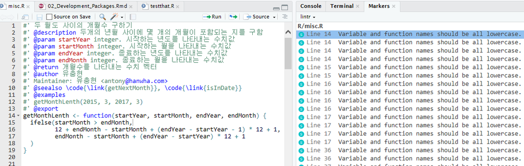

```r
> lintr::lint_package()
```

체크에서 미준수 항목으로 출력된 개별 라인을 수정한 후 `lint_package()` 함수를 재 실행하면서 코드를 수정하면 R 코딩 스타일에 부합하는 코드를 작성할 수 있다.

미준수 항목으로 출력된 개별 라인을 수정하여, `getMonthLenth()` 함수를 다음과 같이 재작성하였다.

```r
get_month_length <- function(startyear, startmonth, endyear, endmonth) {
  ifelse(startmonth > endmonth, 12 + endmonth - startmonth +
    (endyear - startyear - 1) * 12 + 1, endmonth - startmonth +
    (endyear - startyear) * 12 + 1)
}
```

# 3 패키지 관련 파일의 자동 생성

## 3.1 roxygen2

`roxygen2` 패키지는 패키지를 개발할 때 help page를 기술하는 파일인 `Rd` 파일과 `NAMESPACE` 파일을 자동으로 작성해준다.

일반적으로 Rd 파일은 패키지 홈 디렉토리의 man 디렉토리에 *.Rd,* .rd 포맷의 이름으로 만든다. 그런데 `roxygen2` 패키지는 패키지를 정의하는 R 소스 파일에 roxygen 형식으로 스크립트를 작성한 후, 자동으로 Rd 파일을 생성한다.

NAMESPACE 파일에는 **패키지에서 참조하는 다른 패키지나 패키지의 함수를 지정하는 import 정보** 및 **패키지의 함수에 접근할 수 있는 export 정보**를 기술한다.

다음은 roxygen 형식으로 스크립트를 작성한 R 소스 파일의 일부분이다.

```r
#' 두 월도 사이의 개월수 구하기
#' @description 두개의 년월 사이에 몇 개의 개월이 포함되는 지를 구함
#' @param startyear integer. 시작하는 년도를 나타내는 수치값
#' @param startmonth integer. 시작하는 월을 나타내는 수치값
#' @param endyear integer. 종료하는 년도를 나타내는 수치값
#' @param endmonth integer. 종료하는 월을 나타내는 수치값
#' @return 개월수를 나타내는 수치 벡터
#' @author 유충현
#' Maintainer: 유충현 <choonghyun.ryu@gmail.com>
#' @seealso \code{\link{get_next_month}}, \code{\link{is_indate}}
#' @examples
#' get_month_length(2015, 3, 2017, 3)
#' @export
get_month_length <- function(startyear, startmonth, endyear, endmonth) {
  ifelse(startmonth > endmonth, 12 + endmonth - startmonth +
    (endyear - startyear - 1) * 12 + 1, endmonth - startmonth +
    (endyear - startyear) * 12 + 1)
}
```

roxygen 스크립트의 시작은 `#'`로 시작한다. 즉, R 소스 파일에서 `#'`로 시작하는 라인은 roxygen2 패키지가 해석하는 라인이다.

### 3.1.1 roxygen2 태그

roxygen2의 대표적인 태그는 다음과 같다.